# Bayesian First Aid Examples

This document contains examples of all the `bayes.*` functions implemented in Bayesian First aid including example output from the generic functions `plot`, `summary`, `diagnostics` and `model.code`.

## `binom.test`

A classical binomial test:

```r
library(BayesianFirstAid)
binom.test(x = 16, n = 20)
```

```
##
##  Exact binomial test
##
## data:  16 and 20
## number of successes = 16, number of trials = 20, p-value = 0.01182
## alternative hypothesis: true probability of success is not equal to 0.5
## 95 percent confidence interval:
##  0.5634 0.9427
## sample estimates:
## probability of success
##                    0.8
```

Prepend `binom.test` by `bayes.` to run the Bayesian “version”.

```r
bayes.binom.test(x = 16, n = 20)
```

```
##
##  Bayesian First Aid binomial test
##
## data: 16 and 20
## number of successes = 16, number of trials = 20
## Estimated relative frequency of success:
##   0.77
## 95% credible interval:
##   0.60 0.93
## The relative frequency of success is more than 0.5 by a probability of 0.997
## and less than 0.5 by a probability of 0.003
```

The idea is to respect the arguments to the original `binom.test` as far as possible. For example, setting `p` and `conf.level` as in…

```r
binom.test(x = 16, n = 20, p = 0.75, conf.level = 0.8)
```

```
##
##  Exact binomial test
##
## data:  16 and 20
## number of successes = 16, number of trials = 20, p-value = 0.7977
## alternative hypothesis: true probability of success is not equal to 0.75
## 80 percent confidence interval:
##  0.6393 0.9098
## sample estimates:
## probability of success
##                    0.8
```

… is respected by `bayes.binom.test`:

```r
bayes.binom.test(x = 16, n = 20, p = 0.75, conf.level = 0.8)
```

```
##
##  Bayesian First Aid binomial test
##
## data: 16 and 20
## number of successes = 16, number of trials = 20
## Estimated relative frequency of success:
##   0.77
## 80% credible interval:
##   0.68 0.89
## The relative frequency of success is more than 0.75 by a probability of 0.632
## and less than 0.75 by a probability of 0.368
```

By assigning the result of `bayes.binom.test` to a variable we can get some more useful info by calling `plot` for looking at the posterior (and perhaps a posterior predictive check), `summary` for a more extensive summary than the standard print out above, and `diagnostics` for MCMC diagnostics. The idea is that the behavior of these functions should be consistent for all the `bayes.*.test` functions.

```r
(fit <- bayes.binom.test(x = 16, n = 20))
```

```
##
##  Bayesian First Aid binomial test
##
## data: 16 and 20
## number of successes = 16, number of trials = 20
## Estimated relative frequency of success:
##   0.77
## 95% credible interval:
##   0.60 0.93
## The relative frequency of success is more than 0.5 by a probability of 0.996
## and less than 0.5 by a probability of 0.004
```

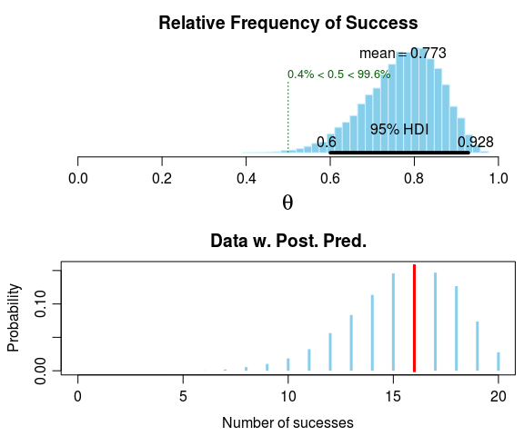

```r
plot(fit)
```

```r
summary(fit)
```

```
##   Data
## number of successes = 16, number of trials = 20
##
##   Model parameters and generated quantities
## theta: the relative frequency of success
## x_pred: predicted number of successes in a replication
##
##   Measures
##          mean    sd HDIlo  HDIup %<comp %>comp
## theta   0.773 0.087   0.6  0.928  0.004  0.996
## x_pred 15.473 2.506  10.0 19.000  0.000  1.000
##
## 'HDIlo' and 'HDIup' are the limits of a 95% HDI credible interval.
## '%<comp' and '%>comp' are the probabilities of the respective parameter being
## smaller or larger than 0.5.
##
##   Quantiles
##         q2.5%   q25% median   q75% q97.5%
## theta   0.581  0.718  0.781  0.837  0.917
## x_pred 10.000 14.000 16.000 17.000 20.000
```

```r
diagnostics(fit)
```

```
##
## Iterations = 1:5000
## Thinning interval = 1
## Number of chains = 3
## Sample size per chain = 5000
##
##   Diagnostic measures
##          mean    sd mcmc_se n_eff Rhat
## theta   0.773 0.087   0.001 14999    1
## x_pred 15.473 2.506   0.020 15000    1
##
## mcmc_se: the estimated standard error of the MCMC approximation of the mean.
## n_eff: a crude measure of effective MCMC sample size.
## Rhat: the potential scale reduction factor (at convergence, Rhat=1).
##
##   Model parameters and generated quantities
## theta: The relative frequency of success
## x_pred: Predicted number of successes in a replication
```

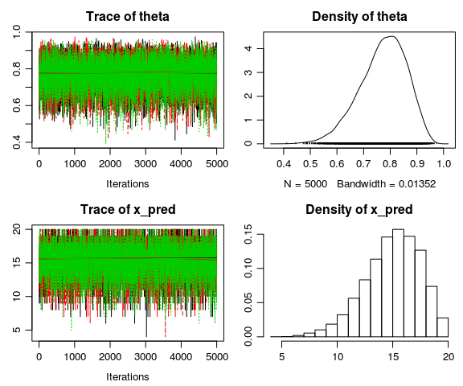

Of course, in the case of `bayes.binom.test` the MCMC diagnostics might be a bit silly…

By asking for the `model.code` we get a print out of a script that runs the same analysis as `bayes.binom.test`. This could be copied into an R-script to study how it works or to modify it further.

```r
model.code(fit)
```

```
## ### Model code for the Bayesian First Aid alternative to the binomial test ###
## require(rjags)
##
## # Setting up the data
## x <- 16
## n <- 20
##
## # The model string written in the JAGS language
## model_string <- "model {
##   x ~ dbinom(theta, n)
##   theta ~ dbeta(1, 1)
##   x_pred ~ dbinom(theta, n)
## }"
##
## # Running the model
## model <- jags.model(textConnection(model_string), data = list(x = x, n = n),
##                     n.chains = 3, n.adapt=1000)
## samples <- coda.samples(model, c("theta", "x_pred"), n.iter=5000)
##
## # Inspecting the posterior
## plot(samples)
## summary(samples)
```

## `t.test`

The alternative for the `t.test` is BEST.

```r
x <- rnorm(n = 30, mean = 2, sd = 5)
t.test(x)
```

```
##
##  One Sample t-test
##
## data:  x
## t = 1.97, df = 29, p-value = 0.05842
## alternative hypothesis: true mean is not equal to 0
## 95 percent confidence interval:
##  -0.06713  3.59610
## sample estimates:
## mean of x
##     1.764
```

```r
bayes.t.test(x, progress.bar = "none")
```

```
##
##  Bayesian estimation supersedes the t test (BEST) - one sample
##
## data: x, n = 30
##
##   Estimates [95% credible interval]
## mean of x: 1.7 [-0.13, 3.6]
## sd of x: 5.0 [3.5, 6.5]
##
## The mean is more than 0 by a probability of 0.965
## and less than 0 by a probability of 0.035
```

`bayes.t.test` also respects the arguments of the original `t.test`.

```r
y <- rnorm(n = 30, mean = 10, sd = 5)
bayes.t.test(x, y, mu = 1, conf.level = 0.5, progress.bar = "none")
```

```
##
##  Bayesian estimation supersedes the t test (BEST) - two sample
##
## data: x and y
##
##   Estimates [50% credible interval]
## mean of x: 1.7 [1.1, 2.3]
## mean of y: 11 [10, 11]
## difference of the means: -9.1 [-9.9, -8.2]
## sd of x: 5.0 [4.3, 5.3]
## sd of y: 4.2 [3.7, 4.5]
##
## The difference of the means is more than 1 by a probability of 0
## and less than 1 by a probability of 1
```

Or even…

```r
# Creating 'paired' data
d <- data.frame(x = rnorm(n = 30, mean = 10, sd = 5), group = rep(c("A", "B"),
    15))

bayes.t.test(x ~ group, paired = T, data = d, progress.bar = "none")
```

```
##
##  Bayesian estimation supersedes the t test (BEST) - paired samples
##
## data: x by group, n = 15
##
##   Estimates [95% credible interval]
## mean paired difference: -0.067 [-3.5, 3.4]
## sd of the paired differences: 6.3 [3.9, 9.1]
##
## The mean difference is more than 0 by a probability of 0.48
## and less than 0 by a probability of 0.52
```

The same generic functions (`plot`, `summary`, `diagnostics`) works for all fitted models from `bayes.t.test`.

### Output one sample ´bayes.t.test´

```r
(fit <- bayes.t.test(x, mu = 1, progress.bar = "none"))
```

```
##
##  Bayesian estimation supersedes the t test (BEST) - one sample
##
## data: x, n = 30
##
##   Estimates [95% credible interval]
## mean of x: 1.7 [-0.21, 3.6]
## sd of x: 5.0 [3.5, 6.4]
##
## The mean is more than 1 by a probability of 0.779
## and less than 1 by a probability of 0.221
```

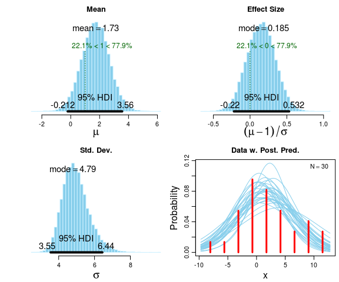

```r
plot(fit)
```

```r
summary(fit)
```

```
##   Data
## x, n = 30
##
##   Model parameters and generated quantities
## mu: the mean of x
## sigma: the standard deviation of x
## nu: the degrees-of-freedom for the t distribution fitted to x
## eff_size: the effect size calculated as (mu - 1) / sigma
## x_pred: predicted distribution for a new datapoint generated as x
##
##   Measures
##            mean     sd  HDIlo  HDIup %<comp %>comp
## mu        1.727  0.960 -0.212  3.561  0.221  0.779
## sigma     4.959  0.745  3.550  6.438  0.000  1.000
## nu       37.308 30.621  1.777 98.517  0.000  1.000
## eff_size  0.149  0.194 -0.220  0.532  1.000  0.000
## x_pred    1.725  5.479 -9.079 12.499  0.440  0.560
##
## 'HDIlo' and 'HDIup' are the limits of a 95% HDI credible interval.
## '%<comp' and '%>comp' are the probabilities of the respective parameter being
## smaller or larger than 1.
##
##   Quantiles
##           q2.5%   q25% median   q75%  q97.5%
## mu       -0.162  1.087  1.731  2.357   3.623
## sigma     3.700  4.443  4.887  5.396   6.629
## nu        4.632 15.500 28.793 49.844 119.500
## eff_size -0.225  0.018  0.151  0.280   0.527
## x_pred   -9.086 -1.657  1.764  5.132  12.496
```

```r
diagnostics(fit)
```

```
##
## Iterations = 601:8934
## Thinning interval = 1
## Number of chains = 3
## Sample size per chain = 8334
##
##   Diagnostic measures
##            mean     sd mcmc_se n_eff  Rhat
## mu        1.727  0.960   0.008 14848 1.000
## sigma     4.959  0.745   0.007 10319 1.000
## nu       37.308 30.621   0.436  5135 1.002
## eff_size  0.149  0.194   0.002 15066 1.000
## x_pred    1.725  5.479   0.035 25001 1.001
##
## mcmc_se: the estimated standard error of the MCMC approximation of the mean.
## n_eff: a crude measure of effective MCMC sample size.
## Rhat: the potential scale reduction factor (at convergence, Rhat=1).
##
##   Model parameters and generated quantities
## mu: the mean of x
## sigma: the standard deviation of x
## nu: the degrees-of-freedom for the t distribution fitted to x
## eff_size: the effect size calculated as (mu - 1) / sigma
## x_pred: predicted distribution for a new datapoint generated as x
```

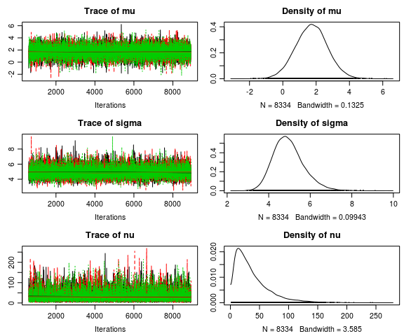

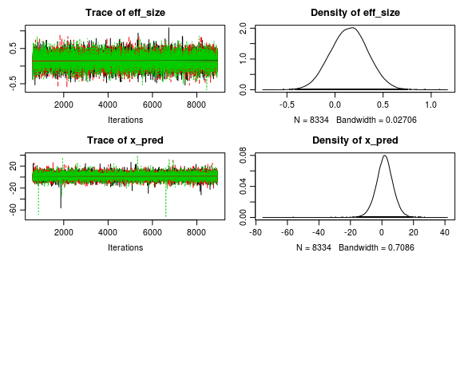

```r
model.code(fit)
```

```
## ### Model code for Bayesian estimation supersedes the t test - one sample ###
## require(rjags)
##
## # Setting up the data
## x <- x
## comp_mu <-  1
##
## # The model string written in the JAGS language
## model_string <- "model {
##   for(i in 1:length(x)) {
##     x[i] ~ dt( mu , tau , nu )
##   }
##   x_pred ~ dt( mu , tau , nu )
##   eff_size <- (mu - comp_mu) / sigma
##
##   mu ~ dnorm( mean_mu , precision_mu )
##   tau <- 1/pow( sigma , 2 )
##   sigma ~ dunif( sigmaLow , sigmaHigh )
##   # A trick to get an exponentially distributed prior on nu that starts at 1.
##   nu <- nuMinusOne + 1
##   nuMinusOne ~ dexp(1/29)
## }"
##
## # Setting parameters for the priors that in practice will result
## # in flat priors on mu and sigma.
## mean_mu = mean(x, trim=0.2)
## precision_mu = 1 / (mad(x)^2 * 1000000)
## sigmaLow = mad(x) / 1000
## sigmaHigh = mad(x) * 1000
##
## # Initializing parameters to sensible starting values helps the convergence
## # of the MCMC sampling. Here using robust estimates of the mean (trimmed)
## # and standard deviation (MAD).
## inits_list <- list(mu = mean(x, trim=0.2), sigma = mad(x), nuMinusOne = 4)
##
## data_list <- list(
##   x = x,
##   comp_mu = comp_mu,
##   mean_mu = mean_mu,
##   precision_mu = precision_mu,
##   sigmaLow = sigmaLow,
##   sigmaHigh = sigmaHigh)
##
## # The parameters to monitor.
## params <- c("mu", "sigma", "nu", "eff_size", "x_pred")
##
## # Running the model
## model <- jags.model(textConnection(model_string), data = data_list,
##                     inits = inits_list, n.chains = 3, n.adapt=1000)
## update(model, 500) # Burning some samples to the MCMC gods....
## samples <- coda.samples(model, params, n.iter=10000)
##
## # Inspecting the posterior
## plot(samples)
## summary(samples)
```

### Output two sample ´bayes.t.test´

```r
(fit <- bayes.t.test(x, y, conf.level = 0.8, progress.bar = "none"))
```

```
##
##  Bayesian estimation supersedes the t test (BEST) - two sample
##
## data: x and y
##
##   Estimates [80% credible interval]
## mean of x: 1.7 [0.55, 2.9]
## mean of y: 11 [9.8, 12]
## difference of the means: -9.1 [-11, -7.6]
## sd of x: 5.0 [4.0, 5.8]
## sd of y: 4.2 [3.3, 4.9]
##
## The difference of the means is more than 0 by a probability of 0
## and less than 0 by a probability of 1
```

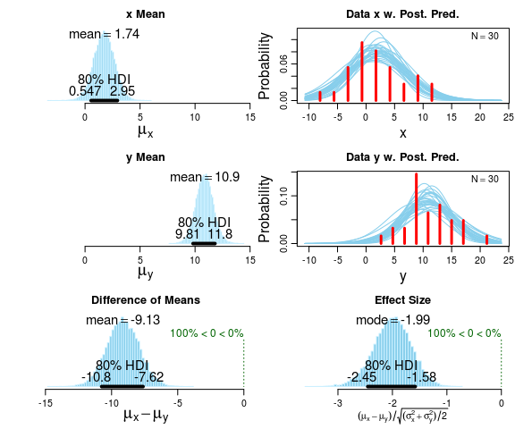

```r
plot(fit)
```

```r
summary(fit)
```

```
##   Data
## x, n = 30
## y, n = 30
##
##   Model parameters and generated quantities
## mu_x: the mean of x
## sigma_x: the standard deviation of x
## mu_y: the mean of y
## sigma_y: the standard deviation of y
## mu_diff: the difference in means (mu_x - mu_y)
## sigma_diff: the difference in SD (sigma_x - sigma_y)
## nu: the degrees-of-freedom for the t distribution
##   fitted to x and y
## eff_size: the effect size calculated as
##   (mu_x - mu_y) / sqrt((sigma_x^2 + sigma_y^2) / 2)
## x_pred: predicted distribution for a new datapoint
##   generated as x
## y_pred: predicted distribution for a new datapoint
##   generated as y
##
##   Measures
##              mean     sd   HDIlo  HDIup %<comp %>comp
## mu_x        1.736  0.948   0.547  2.946  0.033  0.967
## sigma_x     4.974  0.741   3.999  5.804  0.000  1.000
## mu_y       10.871  0.792   9.813 11.811  0.000  1.000
## sigma_y     4.184  0.629   3.335  4.865  0.000  1.000
## mu_diff    -9.135  1.234 -10.752 -7.619  1.000  0.000
## sigma_diff  0.790  0.948  -0.391  1.959  0.193  0.807
## nu         38.556 31.060   3.531 57.734  0.000  1.000
## eff_size   -2.002  0.345  -2.453 -1.580  1.000  0.000
## x_pred      1.727  5.376  -5.140  8.066  0.367  0.633
## y_pred     10.850  4.500   5.168 16.276  0.011  0.989
##
## 'HDIlo' and 'HDIup' are the limits of a 80% HDI credible interval.
## '%<comp' and '%>comp' are the probabilities of the respective parameter being
## smaller or larger than 0.
##
##   Quantiles
##              q2.5%   q25% median   q75%  q97.5%
## mu_x        -0.135  1.109  1.743  2.361   3.556
## sigma_x      3.731  4.458  4.899  5.413   6.623
## mu_y         9.331 10.346 10.870 11.386  12.453
## sigma_y      3.131  3.743  4.121  4.552   5.610
## mu_diff    -11.548 -9.954 -9.142 -8.302  -6.720
## sigma_diff  -1.056  0.167  0.777  1.391   2.716
## nu           5.789 16.735 29.760 50.529 121.795
## eff_size    -2.707 -2.228 -1.995 -1.768  -1.341
## x_pred      -8.951 -1.728  1.744  5.162  12.470
## y_pred       2.045  7.980 10.861 13.702  19.901
```

```r
diagnostics(fit)
```

```
##
## Iterations = 601:8934
## Thinning interval = 1
## Number of chains = 3
## Sample size per chain = 8334
##
##   Diagnostic measures
##              mean     sd mcmc_se n_eff  Rhat
## mu_x        1.736  0.948   0.008 14939 1.000
## sigma_x     4.974  0.741   0.007 11336 1.001
## mu_y       10.871  0.792   0.006 15106 1.000
## sigma_y     4.184  0.629   0.006 11407 1.001
## mu_diff    -9.135  1.234   0.010 15157 1.001
## sigma_diff  0.790  0.948   0.008 12527 1.002
## nu         38.556 31.060   0.470  4732 1.001
## eff_size   -2.002  0.345   0.003 13771 1.001
## x_pred      1.727  5.376   0.034 25002 1.000
## y_pred     10.850  4.500   0.029 24460 1.000
##
## mcmc_se: the estimated standard error of the MCMC approximation of the mean.
## n_eff: a crude measure of effective MCMC sample size.
## Rhat: the potential scale reduction factor (at convergence, Rhat=1).
##
##   Model parameters and generated quantities
## mu_x: the mean of x
## sigma_x: the standard deviation of x
## mu_y: the mean of y
## sigma_y: the standard deviation of y
## mu_diff: the difference in means (mu_x - mu_y)
## sigma_diff: the difference in SD (sigma_x - sigma_y)
## nu: the degrees-of-freedom for the t distribution
##   fitted to x and y
## eff_size: the effect size calculated as
##   (mu_x - mu_y) / sqrt((sigma_x^2 + sigma_y^2) / 2)
## x_pred: predicted distribution for a new datapoint
##   generated as x
## y_pred: predicted distribution for a new datapoint
##   generated as y
```

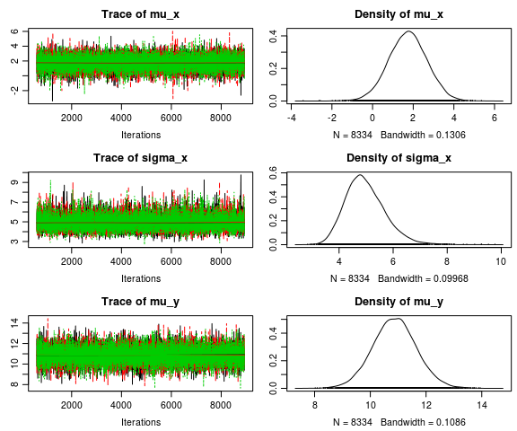

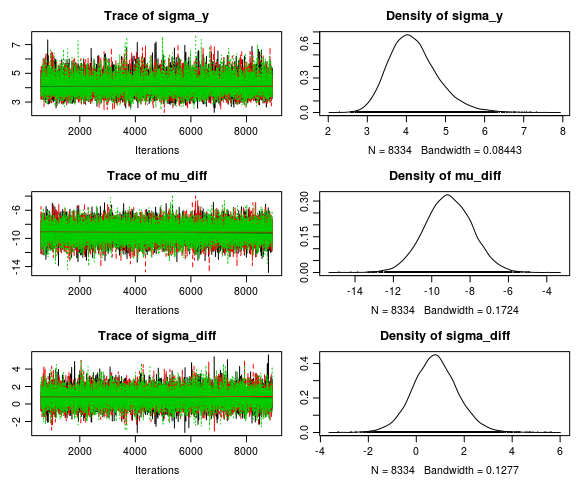

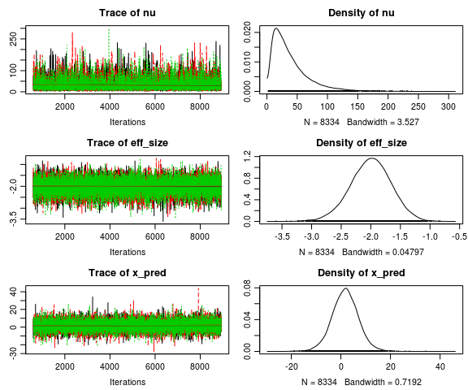

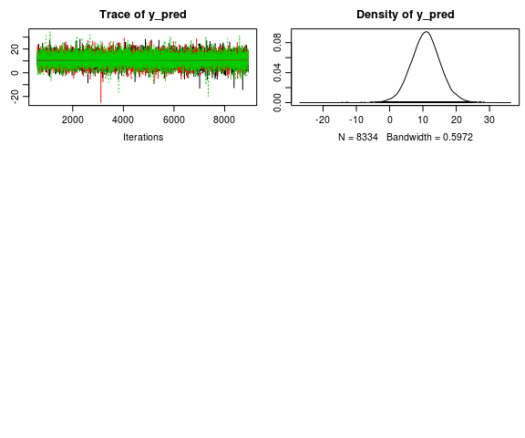

```r
model.code(fit)
```

```
## function(x, y, n.adapt= 500, n.chains=3, n.update = 100, n.iter=5000, thin=1, progress.bar="text") {
##   data_list <- list(
##     x = x ,
##     y = y ,
##     mean_mu = mean(c(x, y), trim=0.2) ,
##     precision_mu = 1 / (mad(c(x, y))^2 * 1000000),
##     sigmaLow = mad(c(x, y)) / 1000 ,
##     sigmaHigh = mad(c(x, y)) * 1000
##   )
##
##   inits_list <- list(
##     mu_x = mean(x, trim=0.2),
##     mu_y = mean(y, trim=0.2),
##     sigma_x = mad(x),
##     sigma_y = mad(y),
##     nuMinusOne = 4
##   )
##
##   params <- c("mu_x", "sigma_x", "mu_y", "sigma_y", "mu_diff", "sigma_diff","nu", "eff_size", "x_pred", "y_pred")
##   mcmc_samples <- run_jags(two_sample_t_model_string, data = data_list, inits = inits_list,
##                            params = params, n.chains = n.chains, n.adapt = n.adapt,
##                            n.update = n.update, n.iter = n.iter, thin = thin, progress.bar=progress.bar)
##   mcmc_samples
## }
## <environment: namespace:BayesianFirstAid>
```

### Output paired samples ´bayes.t.test´

```r
(fit <- bayes.t.test(x ~ group, paired = T, data = d, progress.bar = "none"))
```

```
##
##  Bayesian estimation supersedes the t test (BEST) - paired samples
##
## data: x by group, n = 15
##
##   Estimates [95% credible interval]
## mean paired difference: -0.069 [-3.5, 3.3]
## sd of the paired differences: 6.3 [3.9, 9.1]
##
## The mean difference is more than 0 by a probability of 0.487
## and less than 0 by a probability of 0.513
```

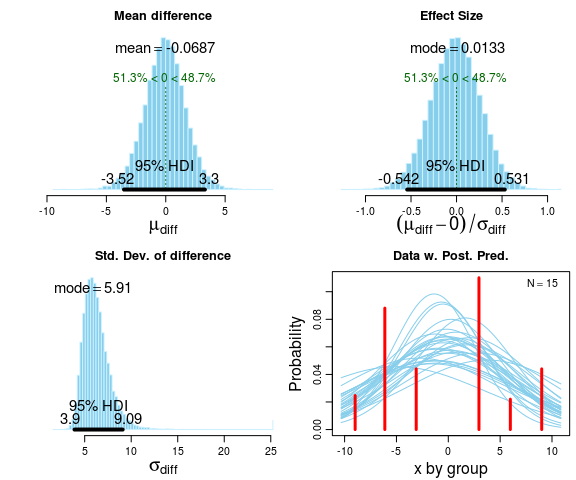

```r
plot(fit)
```

```r
summary(fit)
```

```
##   Data
## group A, n = 15
## group B, n = 15
##
##   Model parameters and generated quantities
## mu_diff: the mean pairwise difference between group A and group B
## sigma_diff: the standard deviation of the pairwise difference
## nu: the degrees-of-freedom for the t distribution fitted to the pairwise difference
## eff_size: the effect size calculated as (mu_diff - 0) / sigma_diff
## diff_pred: predicted distribution for a new datapoint generated
##   as the pairwise difference between group A and group B
##
##   Measures
##              mean     sd   HDIlo  HDIup %<comp %>comp
## mu_diff    -0.069  1.719  -3.519  3.299  0.513  0.487
## sigma_diff  6.271  1.427   3.903  9.086  0.000  1.000
## nu         35.736 29.937   1.656 94.289  0.000  1.000
## eff_size   -0.011  0.272  -0.542  0.531  0.513  0.487
## diff_pred  -0.133  7.199 -14.120 14.242  0.504  0.496
##
## 'HDIlo' and 'HDIup' are the limits of a 95% HDI credible interval.
## '%<comp' and '%>comp' are the probabilities of the respective parameter being
## smaller or larger than 0.
##
##   Quantiles
##              q2.5%   q25% median   q75%  q97.5%
## mu_diff     -3.515 -1.171 -0.051  1.039   3.308
## sigma_diff   4.182  5.286  6.052  7.002   9.630
## nu           4.038 14.480 27.308 48.279 112.702
## eff_size    -0.553 -0.192 -0.008  0.171   0.522
## diff_pred  -14.374 -4.478 -0.078  4.260  14.134
```

```r
diagnostics(fit)
```

```
##
## Iterations = 601:8934
## Thinning interval = 1
## Number of chains = 3
## Sample size per chain = 8334
##
##   Diagnostic measures
##              mean     sd mcmc_se n_eff  Rhat
## mu_diff    -0.069  1.719   0.014 14360 1.000
## sigma_diff  6.271  1.427   0.015  9013 1.005
## nu         35.736 29.937   0.427  5003 1.004
## eff_size   -0.011  0.272   0.002 15239 1.000
## diff_pred  -0.133  7.199   0.046 24180 1.000
##
## mcmc_se: the estimated standard error of the MCMC approximation of the mean.
## n_eff: a crude measure of effective MCMC sample size.
## Rhat: the potential scale reduction factor (at convergence, Rhat=1).
##
##   Model parameters and generated quantities
## mu_diff: the mean pairwise difference between group A and group B
## sigma_diff: the standard deviation of the pairwise difference
## nu: the degrees-of-freedom for the t distribution fitted to the pairwise difference
## eff_size: the effect size calculated as (mu_diff - 0) / sigma_diff
## diff_pred: predicted distribution for a new datapoint generated
##   as the pairwise difference between group A and group B
```

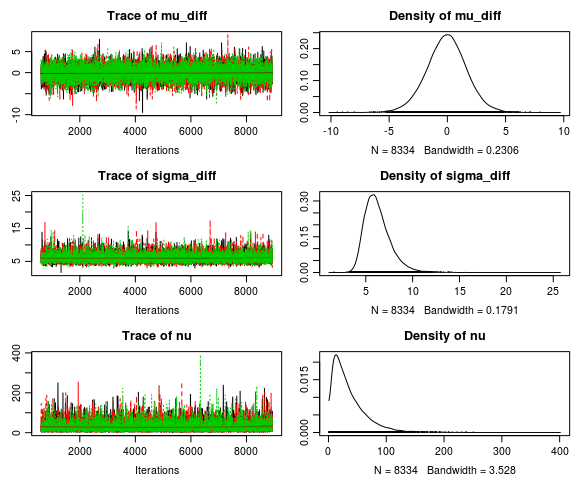

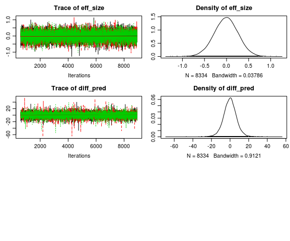

```r
model.code(fit)
```

```
## ## Model code for Bayesian estimation supersedes the t test - paired samples ##
## require(rjags)
##
## # Setting up the data
## x <- subset(d, as.factor(group) == "A", x, drop = TRUE)
## y <- subset(d, as.factor(group) == "B", x, drop = TRUE)
## pair_diff <- x - y
## comp_mu <-  0
##
## # The model string written in the JAGS language
## model_string <- "model {
##   for(i in 1:length(pair_diff)) {
##     pair_diff[i] ~ dt( mu_diff , tau_diff , nu )
## }
## diff_pred ~ dt( mu_diff , tau_diff , nu )
## eff_size <- (mu_diff - comp_mu) / sigma_diff
##
## mu_diff ~ dnorm( mean_mu , precision_mu )
## tau_diff <- 1/pow( sigma_diff , 2 )
## sigma_diff ~ dunif( sigmaLow , sigmaHigh )
## # A trick to get an exponentially distributed prior on nu that starts at 1.
## nu <- nuMinusOne + 1
## nuMinusOne ~ dexp(1/29)
## }"
##
## # Setting parameters for the priors that in practice will result
## # in flat priors on mu and sigma.
## mean_mu = mean(pair_diff, trim=0.2)
## precision_mu = 1 / (mad(pair_diff)^2 * 1000000)
## sigmaLow = mad(pair_diff) / 1000
## sigmaHigh = mad(pair_diff) * 1000
##
## # Initializing parameters to sensible starting values helps the convergence
## # of the MCMC sampling. Here using robust estimates of the mean (trimmed)
## # and standard deviation (MAD).
## inits_list <- list(
##   mu_diff = mean(pair_diff, trim=0.2),
##   sigma_diff = mad(pair_diff),
##   nuMinusOne = 4)
##
## data_list <- list(
##   pair_diff = pair_diff,
##   comp_mu = comp_mu,
##   mean_mu = mean_mu,
##   precision_mu = precision_mu,
##   sigmaLow = sigmaLow,
##   sigmaHigh = sigmaHigh)
##
## # The parameters to monitor.
## params <- c("mu_diff", "sigma_diff", "nu", "eff_size", "diff_pred")
##
## # Running the model
## model <- jags.model(textConnection(model_string), data = data_list,
##                     inits = inits_list, n.chains = 3, n.adapt=1000)
## update(model, 500) # Burning some samples to the MCMC gods....
## samples <- coda.samples(model, params, n.iter=10000)
##
## # Inspecting the posterior
## plot(samples)
## summary(samples)
```

## `poisson.test`

```r
poisson.test(15, 3, r = 3)
```

```
##
##  Exact Poisson test
##
## data:  15 time base: 3
## number of events = 15, time base = 3, p-value = 0.06269
## alternative hypothesis: true event rate is not equal to 3
## 95 percent confidence interval:
##  2.798 8.247
## sample estimates:
## event rate
##          5
```

### Output one sample ´bayes.poisson.test´

```r
(fit <- bayes.poisson.test(15, 3, r = 3))
```

```
##
##  --- Bayesian first aid one sample poisson test ---
##
##
## Iterations = 1:5000
## Thinning interval = 1
## Number of chains = 3
## Sample size per chain = 5000
##
## 1. Empirical mean and standard deviation for each variable,
##    plus standard error of the mean:
##
##           Mean             SD       Naive SE Time-series SE
##         5.1632         1.3084         0.0107         0.0105
##
## 2. Quantiles for each variable:
##
##  2.5%   25%   50%   75% 97.5%
##  2.90  4.23  5.04  5.99  7.98
```

```r
plot(fit)
summary(fit)
```

```
##
## Summary
##
##  --- Bayesian first aid one sample poisson test ---
##
##
## Iterations = 1:5000
## Thinning interval = 1
## Number of chains = 3
## Sample size per chain = 5000
##
## 1. Empirical mean and standard deviation for each variable,
##    plus standard error of the mean:
##
##           Mean             SD       Naive SE Time-series SE
##         5.1632         1.3084         0.0107         0.0105
##
## 2. Quantiles for each variable:
##
##  2.5%   25%   50%   75% 97.5%
##  2.90  4.23  5.04  5.99  7.98
```

```r
diagnostics(fit)
```

```
## Not implemented
```

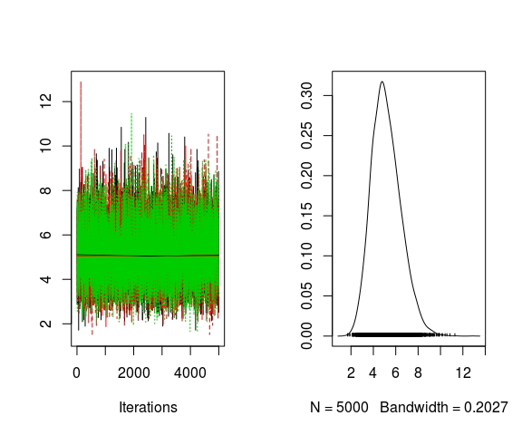

```r
model.code(fit)
```

```
## function(x, t, n.adapt= 500, n.chains=3, n.iter=5000, progress.bar="none") {
##   mcmc_samples <- run_jags(one_sample_poisson_model_string, data = list(x = x, t = t), inits = list(rate = x / t),
##                            params = c("rate"), n.chains = n.chains, n.adapt = n.adapt,
##                            n.update = 0, n.iter = n.iter, thin = 1, progress.bar=progress.bar)
##   mcmc_samples
## }
## <environment: namespace:BayesianFirstAid>
```

### Output two sample ´bayes.poisson.test´

```r
(fit <- bayes.poisson.test(c(15, 20), c(3, 3), r = 1))
```

```
##
##  --- Bayesian first aid two sample poisson test ---
##
##
## Iterations = 1:5000
## Thinning interval = 1
## Number of chains = 3
## Sample size per chain = 5000
##
## 1. Empirical mean and standard deviation for each variable,
##    plus standard error of the mean:
##
##             Mean    SD Naive SE Time-series SE
## rate1      5.171 1.317  0.01075        0.01053
## rate2      6.825 1.522  0.01242        0.01232
## rate_diff  1.654 2.006  0.01637        0.01625
## rate_ratio 0.797 0.281  0.00229        0.00229
##
## 2. Quantiles for each variable:
##
##              2.5%   25%   50%   75% 97.5%
## rate1       2.933 4.213 5.051 5.981  8.07
## rate2       4.161 5.746 6.728 7.767 10.14
## rate_diff  -2.307 0.327 1.649 2.988  5.58
## rate_ratio  0.383 0.597 0.753 0.946  1.47
```

```r
plot(fit)
summary(fit)
```

```
##
## Summary
##
##  --- Bayesian first aid two sample poisson test ---
##
##
## Iterations = 1:5000
## Thinning interval = 1
## Number of chains = 3
## Sample size per chain = 5000
##
## 1. Empirical mean and standard deviation for each variable,
##    plus standard error of the mean:
##
##             Mean    SD Naive SE Time-series SE
## rate1      5.171 1.317  0.01075        0.01053
## rate2      6.825 1.522  0.01242        0.01232
## rate_diff  1.654 2.006  0.01637        0.01625
## rate_ratio 0.797 0.281  0.00229        0.00229
##
## 2. Quantiles for each variable:
##
##              2.5%   25%   50%   75% 97.5%
## rate1       2.933 4.213 5.051 5.981  8.07
## rate2       4.161 5.746 6.728 7.767 10.14
## rate_diff  -2.307 0.327 1.649 2.988  5.58
## rate_ratio  0.383 0.597 0.753 0.946  1.47
```

```r
diagnostics(fit)
```

```
## Not implemented
```

[figure not shown]

```r
model.code(fit)
```

```
## function(x1, t1, x2, t2, n.adapt= 500, n.chains=3, n.iter=5000, progress.bar="none") {
##   data_list = list(x1 = x1, t1 = t1, x2 = x2, t2 = t2)
##   init_list = list(rate1 = x1 / t1, rate2 = x2 / t2)
##   mcmc_samples <- run_jags(two_sample_poisson_model_string, data = data_list, inits = init_list,
##                            params = c("rate1", "rate2", "rate_diff", "rate_ratio"), n.chains = n.chains, n.adapt = n.adapt,
##                            n.update = 0, n.iter = n.iter, thin = 1, progress.bar=progress.bar)
##   mcmc_samples
## }
## <environment: namespace:BayesianFirstAid>
```

## `cor.test`

```r
a = c(-1.5, -1.6, -0.5, -1.5, 0.7, 2.1, -1.3, 0.8)
b = c(-1.9, -1.8, -1.5, -0.6, 0.4, 0.7, -1.7, -1.8)
cor.test(a, b, conf.level = 0.8)
```

```
##
##  Pearson's product-moment correlation
##
## data:  a and b
## t = 2.284, df = 6, p-value = 0.06242
## alternative hypothesis: true correlation is not equal to 0
## 80 percent confidence interval:
##  0.2541 0.8866
## sample estimates:
##   cor
## 0.682
```

### Output ´bayes.cor.test´

```r
(fit <- bayes.cor.test(a, b, conf.level = 0.8, progress.bar = "none"))
```

```
##
##  --- Bayesian first aid cor test ---
##
##
## Iterations = 601:5600
## Thinning interval = 1
## Number of chains = 3
## Sample size per chain = 5000
##
## 1. Empirical mean and standard deviation for each variable,
##    plus standard error of the mean:
##
##            Mean     SD Naive SE Time-series SE
## rho       0.529  0.287  0.00234        0.00489
## mu[1]    -0.425  0.688  0.00562        0.01410
## mu[2]    -1.078  0.494  0.00403        0.00861
## sigma[1]  1.726  0.643  0.00525        0.01455
## sigma[2]  1.295  0.451  0.00368        0.00883
## nu       33.555 29.899  0.24412        0.55412
##
## 2. Quantiles for each variable:
##
##            2.5%    25%    50%     75%    97.5%
## rho      -0.190  0.371  0.588  0.7463   0.9138
## mu[1]    -1.776 -0.812 -0.431 -0.0439   0.9224
## mu[2]    -2.030 -1.377 -1.082 -0.7774  -0.0929
## sigma[1]  0.920  1.302  1.592  1.9880   3.2679
## sigma[2]  0.705  0.988  1.201  1.5018   2.4288
## nu        3.413 12.635 24.617 44.7642 116.0314
```

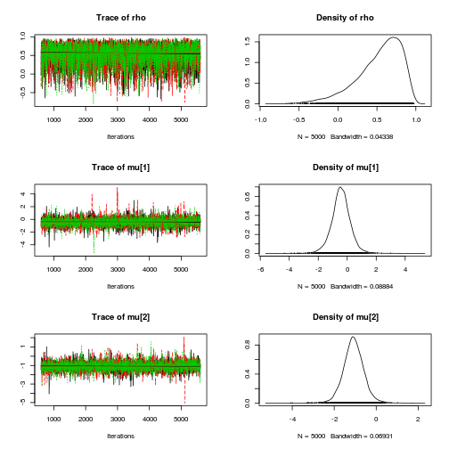

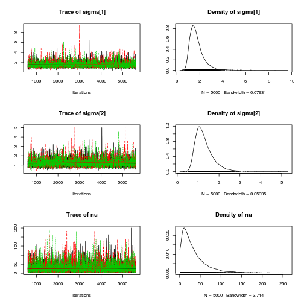

```r
plot(fit)
```

```r
summary(fit)
```

```
##
## Summary
##
##  --- Bayesian first aid cor test ---
##
##
## Iterations = 601:5600
## Thinning interval = 1
## Number of chains = 3
## Sample size per chain = 5000
##
## 1. Empirical mean and standard deviation for each variable,
##    plus standard error of the mean:
##
##            Mean     SD Naive SE Time-series SE
## rho       0.529  0.287  0.00234        0.00489
## mu[1]    -0.425  0.688  0.00562        0.01410
## mu[2]    -1.078  0.494  0.00403        0.00861
## sigma[1]  1.726  0.643  0.00525        0.01455
## sigma[2]  1.295  0.451  0.00368        0.00883
## nu       33.555 29.899  0.24412        0.55412
##
## 2. Quantiles for each variable:
##
##            2.5%    25%    50%     75%    97.5%
## rho      -0.190  0.371  0.588  0.7463   0.9138
## mu[1]    -1.776 -0.812 -0.431 -0.0439   0.9224
## mu[2]    -2.030 -1.377 -1.082 -0.7774  -0.0929
## sigma[1]  0.920  1.302  1.592  1.9880   3.2679
## sigma[2]  0.705  0.988  1.201  1.5018   2.4288
## nu        3.413 12.635 24.617 44.7642 116.0314
```

```r
diagnostics(fit)
```

```
## Not implemented
```

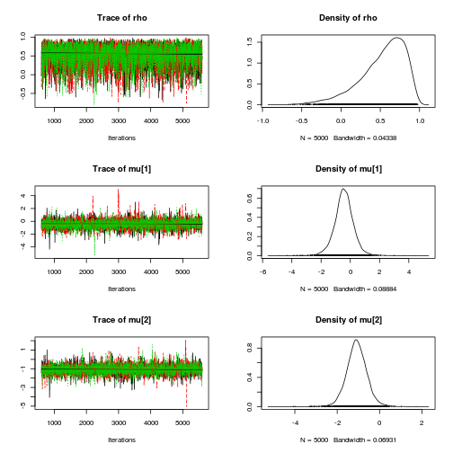

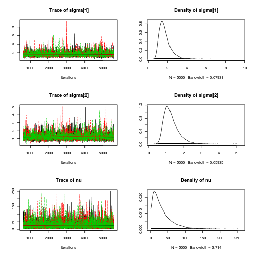

```r
model.code(fit)
```

```
## function(x, y, n.adapt= 500, n.chains=3, n.update = 100, n.iter=5000, thin=1, progress.bar="text") {
##   data_list = list(xy = cbind(x, y), n = length(x))
##   # Use robust estimates of the parameters as initial values
##   inits_list = list(mu=c(mean(x, trim=0.2), mean(y, trim=0.2)), rho=cor(x, y, method="spearman"),
##                     sigma = c(mad(x), mad(y)), nuMinusOne = 5)
##   mcmc_samples <- run_jags(cor_model_string, data = data_list, inits = inits_list,
##                            params = c("rho", "mu", "sigma", "nu"), n.chains = n.chains, n.adapt = n.adapt,
##                            n.update = n.update, n.iter = n.iter, thin = thin, progress.bar=progress.bar)
##   mcmc_samples
## }
## <environment: namespace:BayesianFirstAid>
```